# INST 314 - Week 13 Lab - Spring 2021

04-22-21

## A. Chi-Square Analysis

### 1

*Using R, load the data, check the variables, and find those that you will need to create a contingency table for showing top choice of water versus their usual water source. Label your rows and columns.*

Read the WaterTaste CSV file into a variable `water`.

```r
water <- read.csv("./WaterTaste.csv")
```

Display the labels/columns present in the dataset

```r
ls(water)
```

```
##  [1] "Age"            "Class"          "FavBotWatBrand" "First"
##  [5] "Fourth"         "Gender"         "Preference"     "Second"
##  [9] "Third"          "UsuallyDrink"
```

Display a contingency table for the data in the dataset using `table` and data factoring. Here we see the analysis of top vs usual source choices.

```r
freq_table <- table(as.factor(water$First), as.factor(water$UsuallyDrink))
freq_table
```

```
##
##              Bottled Filtered Tap
##   Aquafina        14        4   7
##   Fiji            15       10  16
##   SamsChoice       8        9   7
##   Tap              4        3   3
```

### 2

*State valid null and alternative hypotheses for the chi-square test of independence.*

1. Null Hypothesis H<sub>0</sub>: The first water choice and usual water choices for each individual are independent of one-another.
2. Alt. Hypothesis H<sub>A</sub>: The opposite of H<sub>0</sub> is the case, where the distribution of the first water choice and the usual water choices ARE dependent upon eachother.

### 3

*Using R, conduct a chi-square test of independence with this data.*

```r
chisq.test(freq_table)
```

```
##
##  Pearson's Chi-squared test
##
## data:  freq_table
## X-squared = 4.9725, df = 6, p-value = 0.5473
```

### 5

*Based on your analysis, is there evidence that the top choices for taste preference are associated with whether or not people usually drink bottled water? If there is a significant association between these two variables, describe how they are related.*

## B. Analysis of Variance (ANOVA)

*Load the data, check the variables, and find those that you will need for this assignment. Optional: Subset the dataset to only retain the variables that you need for this analysis.*

```r
cereal <- read.csv("./Cereal.csv")
```

Display the labels/columns present in the dataset

```r
ls(cereal)
```

```
##  [1] "Calories" "Carbs"    "Company"  "Fat"      "Fiber"    "Name"
##  [7] "Protein"  "Serving"  "Sodium"   "Sugars"
```

### 1

*Summarize your data.*

1. Create a table of summary statistics, showing the sample size, mean, and standard deviation for each company.

```r
attach(cereal)
```

```r
dim(cereal)
```

```
## [1] 30 10
```

```r
names(cereal)
```

```
##  [1] "Name"     "Company"  "Serving"  "Calories" "Fat"      "Sodium"
##  [7] "Carbs"    "Fiber"    "Sugars"   "Protein"
```

```r
str(cereal)
```

```
## 'data.frame':    30 obs. of  10 variables:
##  $ Name    : chr  "AppleJacks" "Boo Berry" "Cap'n Crunch" "Cinnamon Toast Crunch" ...
##  $ Company : chr  "K" "G" "Q" "G" ...
##  $ Serving : num  1 1 0.75 0.75 1 1 1 1 1 1 ...
##  $ Calories: int  117 118 144 169 130 117 117 101 117 113 ...
##  $ Fat     : num  0.6 0.8 2.1 4.4 1.2 1 0.9 0.1 0.2 0.3 ...
##  $ Sodium  : int  143 211 269 408 135 171 178 202 120 229 ...
##  $ Carbs   : int  27 27 31 32 29 26 26 24 28 26 ...
##  $ Fiber   : num  0.5 0.1 1.1 1.7 0.8 0.8 0.5 0.8 0.3 0.1 ...
##  $ Sugars  : num  15 14 16 13.3 16 14 13 3 15 3 ...
##  $ Protein : num  1 1 1.3 2.7 1 1 1 2 1 2 ...
```

```r
head(cereal)
```

|  | Name | Company | Serving | Calories | Fat | Sodium | Carbs | Fiber | Sugars | Protein |
| --- | --- | --- | --- | --- | --- | --- | --- | --- | --- | --- |
| 1 | AppleJacks | K | 1.00 | 117 | 0.6 | 143 | 27 | 0.5 | 15.0 | 1.0 |
| 2 | Boo Berry | G | 1.00 | 118 | 0.8 | 211 | 27 | 0.1 | 14.0 | 1.0 |
| 3 | Cap'n Crunch | Q | 0.75 | 144 | 2.1 | 269 | 31 | 1.1 | 16.0 | 1.3 |
| 4 | Cinnamon Toast Crunch | G | 0.75 | 169 | 4.4 | 408 | 32 | 1.7 | 13.3 | 2.7 |
| 5 | Cocoa Blasts | Q | 1.00 | 130 | 1.2 | 135 | 29 | 0.8 | 16.0 | 1.0 |
| 6 | Cocoa Puffs | G | 1.00 | 117 | 1.0 | 171 | 26 | 0.8 | 14.0 | 1.0 |

```r
summary(cereal)
```

```
##      Name             Company             Serving          Calories
##  Length:30          Length:30          Min.   :0.7500   Min.   : 80.0
##  Class :character   Class :character   1st Qu.:0.8125   1st Qu.:113.2
##  Mode  :character   Mode  :character   Median :1.0000   Median :118.0
##                                        Mean   :0.9683   Mean   :133.8
##                                        3rd Qu.:1.0000   3rd Qu.:160.0
##                                        Max.   :1.5000   Max.   :214.0
##       Fat            Sodium          Carbs           Fiber
##  Min.   :0.100   Min.   :  5.0   Min.   :17.00   Min.   :0.000
##  1st Qu.:0.625   1st Qu.:183.8   1st Qu.:25.00   1st Qu.:0.575
##  Median :0.950   Median :217.0   Median :27.50   Median :0.950
##  Mean   :1.283   Mean   :220.2   Mean   :29.67   Mean   :1.797
##  3rd Qu.:1.525   3rd Qu.:251.2   3rd Qu.:32.75   3rd Qu.:2.800
##  Max.   :4.400   Max.   :408.0   Max.   :47.00   Max.   :7.300
##      Sugars         Protein
##  Min.   : 1.60   Min.   :1.00
##  1st Qu.: 4.50   1st Qu.:1.30
##  Median :12.50   Median :2.00
##  Mean   :10.42   Mean   :2.48
##  3rd Qu.:14.53   3rd Qu.:3.75
##  Max.   :20.00   Max.   :7.00
```

```r
company_K <- filter(Company == "K", TRUE)
sd(company_K)
```

```
## [1] 0.4901325
```

```r
company_G <- filter(cereal$Company == "G", TRUE)
sd(company_G)
```

```
## [1] 0.5040069
```

```r
company_Q <- filter(cereal$Company == "Q", TRUE)
sd(company_Q)
```

```
## [1] 0.4068381
```

Or… Using `tapply` from the lectures to find mean:

```r
tapply(Fiber, Company, mean)
```

```
##        G        K        Q
## 1.469231 1.763636 2.566667
```

To find standard dev.:

```r
tapply(Fiber, Company, sd)
```

```
##        G        K        Q
## 1.247921 2.349158 2.174090
```

To find the summary of fiber contents:

```r
tapply(Fiber, Company, summary)
```

```
## $G
##    Min. 1st Qu.  Median    Mean 3rd Qu.    Max.
##   0.000   0.500   1.300   1.469   2.800   3.700
##
## $K
##    Min. 1st Qu.  Median    Mean 3rd Qu.    Max.
##   0.000   0.400   0.800   1.764   1.900   7.300
##
## $Q
##    Min. 1st Qu.  Median    Mean 3rd Qu.    Max.
##   0.800   0.950   1.900   2.567   3.300   6.400
```

```r
#install.packages("dplyr")
library(dplyr)
group_by(cereal, Company) %>%
  summarize(
    count = n(),
    mean = mean(Fiber, na.rm = TRUE),
    sd = sd(Fiber, na.rm = TRUE)
  )
```

| Company | count | mean | sd |
| --- | --- | --- | --- |
| G | 13 | 1.469231 | 1.247921 |
| K | 11 | 1.763636 | 2.349158 |
| Q | 6 | 2.566667 | 2.174090 |

2. Create a plot of side-by-side boxplots. Comment on whether you are seeing any potential differences in the mean number of grams of fiber per serving, based on the three different companies.

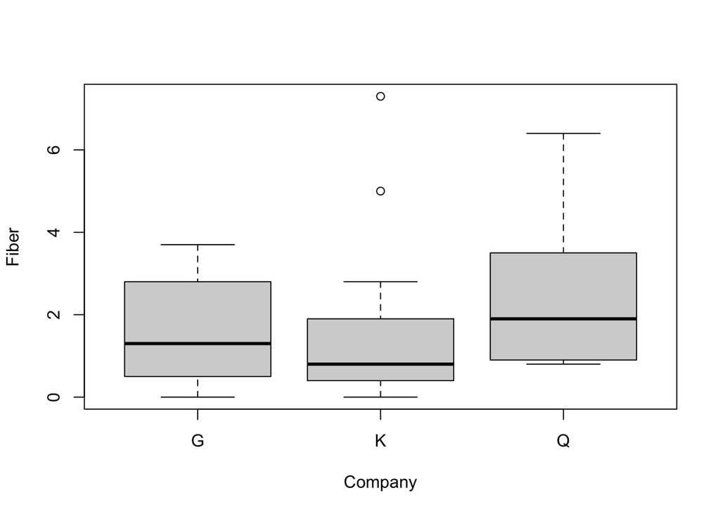

```r
boxplot(Fiber ~ Company)
```

This is nothing more than a visual representation of what we saw (numerically) above. Company `G` has a mean of `~1.5`, company `K` has a mean of `~1.8`, and `Q` has a mean of `~2.6`. Obviously, the most significant difference would be revolving around company `Q`, but no MAJOR differences in the mean number of grams of fiber per serving exist.

### 2

*Check to see if the conditions for ANOVA are met. Interpret your results in the context of this problem, using complete sentence(s). State any limitations to using the traditional ANOVA test.*

From the lecture examples, we can use `tapply` to “mass-call” the `qqnorm` function. This would be “step 1” of the condition checking, where we can visually check the normality of the companies’ fiber distribution.

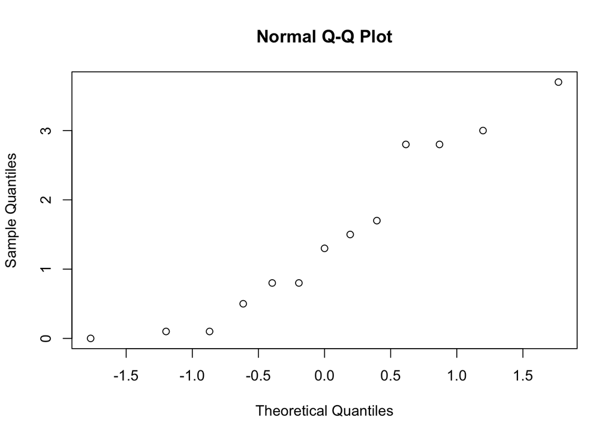

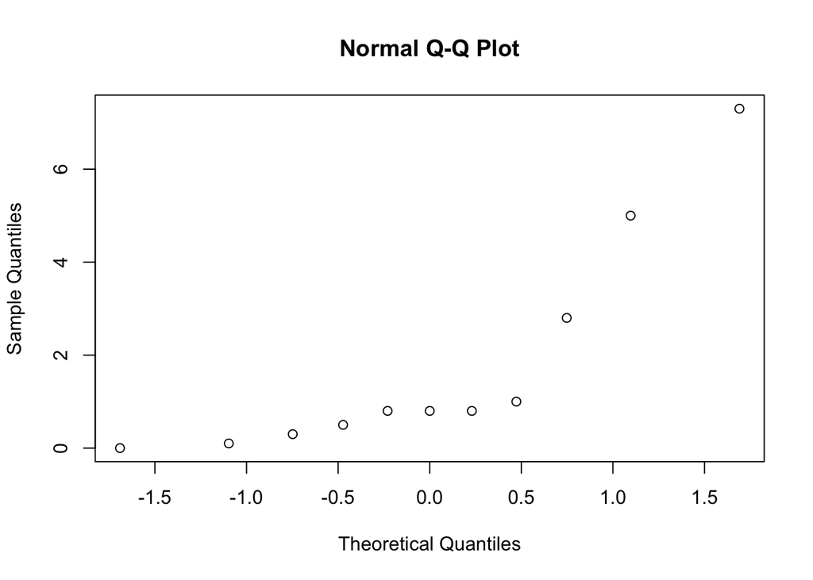

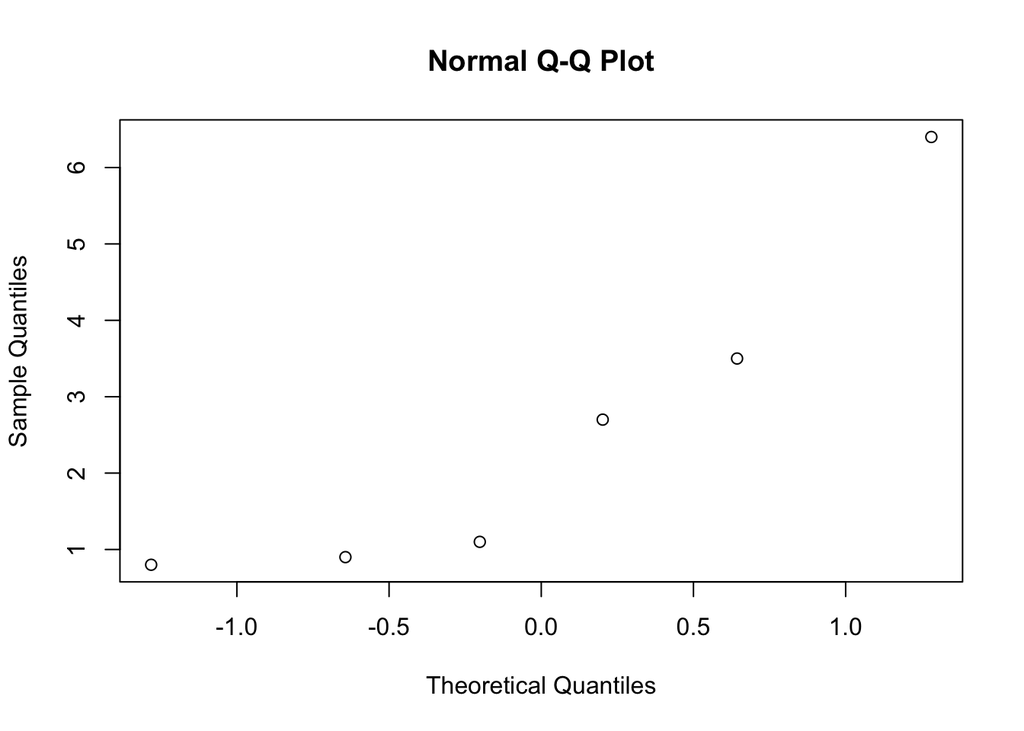

[output not shown]

```r
tapply(Fiber, Company, qqnorm)
```

Step two of the test for applicability, we need to check the “homogeneity” of the different groups–Aka, we’re checking for the variance within the groups. To do this, we can use the `leveneTest` function as discussed in the lecture.

```r
#install.packages("car")
library("car")
leveneTest(Fiber ~ Company, data = cereal)
```

|  | Df | F value | Pr(>F) |
| --- | --- | --- | --- |
| group | 2 | 0.3964204 | 0.6765753 |
|  | 27 | NA | NA |

As we just found out with both of the above tests, (a) There is not the minimum required amount of 30 observations per group OR (b) The data must be normally distributed These requirements are not met with our data, and will affect the ANOVA test.

### 3

*State the hypotheses for this ANOVA using either words or symbols.*

1. H<sub>0</sub>: All of the companies have the same level of fiber per serving. (I.E. `K$Fiber` = `G$Fiber` = `Q$Fiber`)
2. H<sub>A</sub>: There are differences among the number grams of fiber per serving. (I.E. `K` != `G` || `Q` != `K` || `G` != `Q`, vise-versa)

### 4

*Perform the ANOVA and two way comparisons.*

1. Interpret the results of your ANOVA table in the context of this problem, using complete sentence(s).

```r
aov.all <- aov(Fiber ~ Company, data = cereal)
```

```r
summary(aov.all)
```

```
##             Df Sum Sq Mean Sq F value Pr(>F)
## Company      2   4.96   2.482   0.687  0.512
## Residuals   27  97.51   3.611
```

The main statistic that we’re interested in is the `F value` provided in the above table. The `F-value` or `F-statistic` is a representation of a ratio of th varaibility between groups to the average variability within groups. With that being said; Evaluating mainly the F-statistic of `~0.69` given from the above command, we can see that there is a slight varability between the given groups `G`, `Q`, and `K` in measuring the fiber content per serving.

2. Interpret the results of your two-way comparisons in the context of this problem, using complete sentence(s).

```r
TukeyHSD(aov.all)
```

```
##   Tukey multiple comparisons of means
##     95% family-wise confidence level
##
## Fit: aov(formula = Fiber ~ Company, data = cereal)
##
## $Company
##          diff       lwr      upr     p adj
## K-G 0.2944056 -1.635883 2.224694 0.9244212
## Q-G 1.0974359 -1.228052 3.422924 0.4807525
## Q-K 0.8030303 -1.588286 3.194347 0.6863728
```

### 5

*Perform an analysis of the power of this test. Comment on the power of this test. What could be done to improve the power? What other limitations, if any, do you note in this test?*

```r
#install.packages("sjstats")
library("sjstats")
effectsize::eta_squared(aov.all)
```

```
## For one-way between subjects designs, partial eta squared is equivalent to eta squared.
## Returning eta squared.
```

|  | Parameter | Eta2 | CI | CI_low | CI_high |
| --- | --- | --- | --- | --- | --- |
| 1 | Company | 0.04843567 | 0.9 | 0 | 0.1025593 |

```r
#install.packages("pwr")
library("pwr")
pwr.anova.test(k = 3, sig.level = 0.05, f = 0.05, n = 10, power = NULL)
```

```
##
##      Balanced one-way analysis of variance power calculation
##
##               k = 3
##               n = 10
##               f = 0.05
##       sig.level = 0.05
##           power = 0.05507878
##
## NOTE: n is number in each group
```

```r
pwr.anova.test(k = 3, sig.level = 0.05, f = 0.05, n = NULL, power = 0.8)
```

```
##
##      Balanced one-way analysis of variance power calculation
##
##               k = 3
##               n = 1285.624
##               f = 0.05
##       sig.level = 0.05
##           power = 0.8
##
## NOTE: n is number in each group
```

```r
kruskal.test(Fiber ~ Company, data = cereal)
```

```
##
##  Kruskal-Wallis rank sum test
##
## data:  Fiber by Company
## Kruskal-Wallis chi-squared = 2.0418, df = 2, p-value = 0.3603
```